# *Model Development* Disciplined Process

In ES103, we followed the following general procedure for building models of systems.

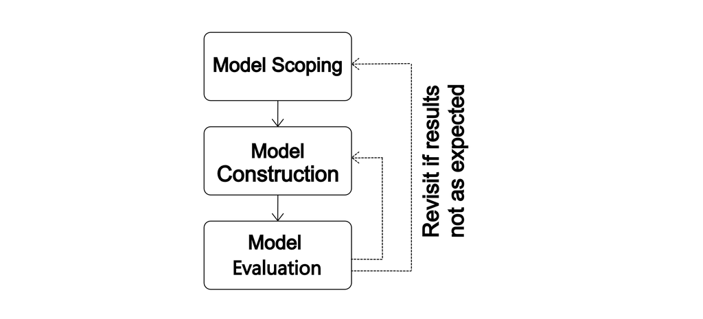

Our scoping and construction steps were primarily physics-based in ES103, but with the addition of some mathematical tools that will allow us to develop *data-driven* solutions to differential equations, we will increase our ability to fit good parameters to physics-based models of dynamic systems.

In ES103, we [did this](https://alexanderallenbrown.github.io/ES103_SP22_Students/Reading_06/Reading_06.html#Empirical-Models:-fitting-polynomials-in-MATLAB/Octave) by fitting a line to the relationship between a system's output and the derivative of its output. This was OK, but now that your experience includes a course in differential equations, we have more tools available to us. These tools are described in the following sections.

## *Model Development:* Mathematical Models

There are many strategies for developing equations of motion that describe the *dynamics* (motion) of a system. You've been exposed to several in your career as an engineering student. In this course, the dynamic models you will see are *differential equations* that relate a model's inputs to its outputs. In this course, we will use one of two general approaches to develop a system's governing differential equation:

1. **Data-driven approach:** Conduct one or more experiments, and allow the experiments' results to guide model assumptions, complexity and structure. *Validate* the model using a *different* set of experiments that show the model has *predictive* power. This is an approach that leans heavily on *inductive* reasoning.
2. **Bottom-up approach:** Begin with physics-based models of each component using appropriate assumptions. Build a model by connecting the system's components and capturing their interactions using the principles of continuity and compatibility. This is an approach that leans heavily on *deductive* reasoning.

Both of these approaches can be valid. Often, some combination of both strategies is necessary before a model is complete. Today, we will focus on the first steps towards building a model using a *Data-driven* approach.